# Telecom Customer Churn Analysis

## Objective

The primary objective of this analysis is to understand why customers are leaving (churning) from a telecom company.  
By examining customer data, I aim to identify the key drivers behind churn, uncover patterns, and provide actionable insights that can help reduce customer turnover and improve retention.

### Business Problem

Customer churn poses a significant challenge for telecom companies.  
Losing customers not only affects revenue but also increases the cost of acquiring new ones.  
Retaining existing customers is more cost-effective than attracting new ones—so understanding the reasons behind churn is critical for maintaining long-term profitability and customer satisfaction.

### Key Questions to Explore

- What percentage of customers are churning?
- Are there specific customer groups (by contract, service type, etc.) more likely to churn?
- Do monthly charges or other service-related factors influence churn behavior?
- What business actions can be taken to proactively reduce churn?

## Prepare and Load the Dataset

### For better visuals and load the dataset

```python
import pandas as pd
import numpy as np
import matplotlib.pyplot as plt
import seaborn as sns
```

```python
sns.set(style="whitegrid")
df = pd.read_csv('telco.csv')
```

### View first few rows

```python
df.head()
```

|  | customerID | gender | SeniorCitizen | Partner | Dependents | tenure | PhoneService | MultipleLines | InternetService | OnlineSecurity | ... | DeviceProtection | TechSupport | StreamingTV | StreamingMovies | Contract | PaperlessBilling | PaymentMethod | MonthlyCharges | TotalCharges | Churn |
| --- | --- | --- | --- | --- | --- | --- | --- | --- | --- | --- | --- | --- | --- | --- | --- | --- | --- | --- | --- | --- | --- |
| 0 | 7590-VHVEG | Female | 0 | Yes | No | 1 | No | No phone service | DSL | No | ... | No | No | No | No | Month-to-month | Yes | Electronic check | 29.85 | 29.85 | No |
| 1 | 5575-GNVDE | Male | 0 | No | No | 34 | Yes | No | DSL | Yes | ... | Yes | No | No | No | One year | No | Mailed check | 56.95 | 1889.5 | No |
| 2 | 3668-QPYBK | Male | 0 | No | No | 2 | Yes | No | DSL | Yes | ... | No | No | No | No | Month-to-month | Yes | Mailed check | 53.85 | 108.15 | Yes |
| 3 | 7795-CFOCW | Male | 0 | No | No | 45 | No | No phone service | DSL | Yes | ... | Yes | Yes | No | No | One year | No | Bank transfer (automatic) | 42.30 | 1840.75 | No |
| 4 | 9237-HQITU | Female | 0 | No | No | 2 | Yes | No | Fiber optic | No | ... | No | No | No | No | Month-to-month | Yes | Electronic check | 70.70 | 151.65 | Yes |

5 rows × 21 columns

### Shape of the data

```python
df.shape
```

```
(7043, 21)
```

### Dataset info

```python
df.info()
```

```
<class 'pandas.core.frame.DataFrame'>
RangeIndex: 7043 entries, 0 to 7042
Data columns (total 21 columns):
 #   Column            Non-Null Count  Dtype
---  ------            --------------  -----
 0   customerID        7043 non-null   object
 1   gender            7043 non-null   object
 2   SeniorCitizen     7043 non-null   int64
 3   Partner           7043 non-null   object
 4   Dependents        7043 non-null   object
 5   tenure            7043 non-null   int64
 6   PhoneService      7043 non-null   object
 7   MultipleLines     7043 non-null   object
 8   InternetService   7043 non-null   object
 9   OnlineSecurity    7043 non-null   object
 10  OnlineBackup      7043 non-null   object
 11  DeviceProtection  7043 non-null   object
 12  TechSupport       7043 non-null   object
 13  StreamingTV       7043 non-null   object
 14  StreamingMovies   7043 non-null   object
 15  Contract          7043 non-null   object
 16  PaperlessBilling  7043 non-null   object
 17  PaymentMethod     7043 non-null   object
 18  MonthlyCharges    7043 non-null   float64
 19  TotalCharges      7043 non-null   object
 20  Churn             7043 non-null   object
dtypes: float64(1), int64(2), object(18)
memory usage: 1.1+ MB
```

### Summary statistics

```python
df.describe()
```

|  | SeniorCitizen | tenure | MonthlyCharges |
| --- | --- | --- | --- |
| count | 7043.000000 | 7043.000000 | 7043.000000 |
| mean | 0.162147 | 32.371149 | 64.761692 |
| std | 0.368612 | 24.559481 | 30.090047 |
| min | 0.000000 | 0.000000 | 18.250000 |
| 25% | 0.000000 | 9.000000 | 35.500000 |
| 50% | 0.000000 | 29.000000 | 70.350000 |
| 75% | 0.000000 | 55.000000 | 89.850000 |
| max | 1.000000 | 72.000000 | 118.750000 |

### Check null values

```python
df.isnull().sum()
```

```
customerID          0
gender              0
SeniorCitizen       0
Partner             0
Dependents          0
tenure              0
PhoneService        0
MultipleLines       0
InternetService     0
OnlineSecurity      0
OnlineBackup        0
DeviceProtection    0
TechSupport         0
StreamingTV         0
StreamingMovies     0
Contract            0
PaperlessBilling    0
PaymentMethod       0
MonthlyCharges      0
TotalCharges        0
Churn               0
dtype: int64
```

## Exploratory Data Analysis (EDA)

### Churn Value counts

```python
df['Churn'].value_counts()
```

```
No     5174
Yes    1869
Name: Churn, dtype: int64
```

### Pie chart- Churn Rate

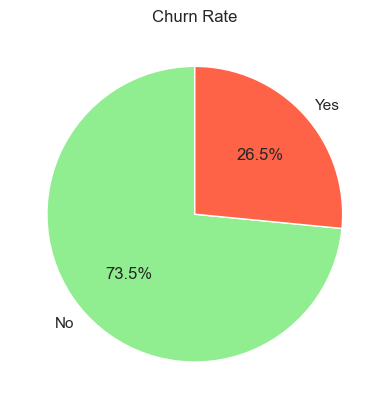

```python
df['Churn'].value_counts().plot(kind='pie', autopct='%1.1f%%', startangle=90, colors=['lightgreen', 'tomato'])
plt.title('Churn Rate')
plt.ylabel('')
plt.show()
```

### Churn by Contract Type

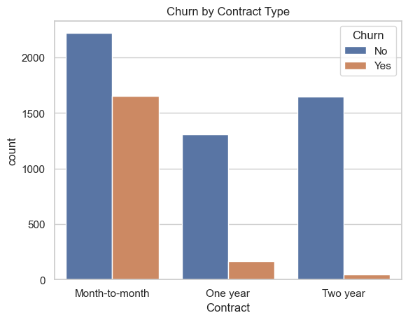

```python
sns.countplot(x='Contract', hue='Churn', data=df)
plt.title('Churn by Contract Type')
plt.show()
```

### Insight:

- Most churn happens in month-to-month contracts.
- Customers with 1 or 2-year contracts are more loyal and less likely to churn.

### Churn by Internet Service

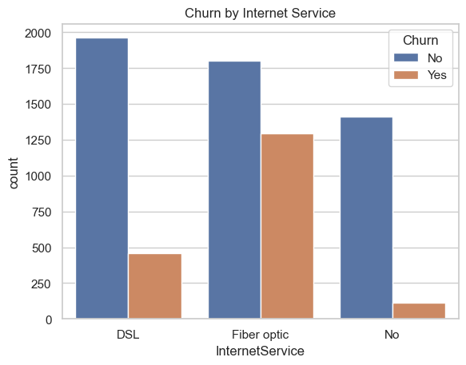

```python
sns.countplot(x='InternetService', hue='Churn', data=df)
plt.title('Churn by Internet Service')
plt.show()
```

### Monthly Charges Distribution

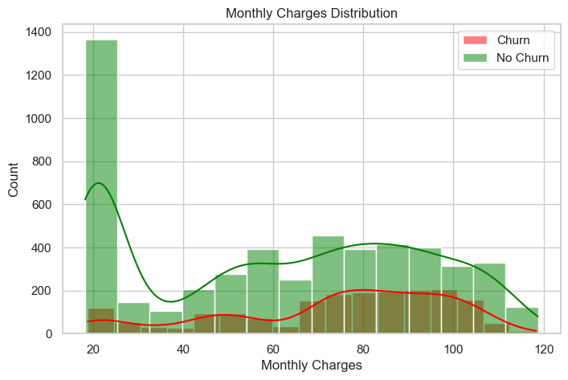

```python
plt.figure(figsize=(8,5))
sns.histplot(df[df['Churn']=='Yes']['MonthlyCharges'], color='red', label='Churn', kde=True)
sns.histplot(df[df['Churn']=='No']['MonthlyCharges'], color='green', label='No Churn', kde=True)
plt.legend()
plt.title('Monthly Charges Distribution')
plt.xlabel('Monthly Charges')
plt.show()
```

### Insight:

- Churned customers mostly have high monthly charges (₹70–₹100).
- Non-churned customers are spread out but many have lower charges (₹20–₹40).

## Summary of Insights

### 2. Churn by Contract Type:

- Customers on **month-to-month contracts** have the highest churn rate, which suggests that **short-term commitments** may lead to **dissatisfaction** or **indecision** about staying with the service.
- **1-year** and **2-year contracts** show significantly **lower churn rates**, indicating that customers with longer-term commitments are generally more satisfied and more likely to stay.

### 4. Churn and Monthly Charges:

- Customers with **higher monthly charges** (₹70-₹100) are more likely to churn, suggesting they might feel they are not receiving **adequate value** for the cost.
- Customers who stay tend to have **lower monthly charges**, indicating that **pricing** plays a significant role in customer retention and satisfaction.

## Recommendations

### 1. Reevaluate Contract Offerings:

- Consider offering **longer-term contracts** with **added incentives** (e.g., discounts or exclusive benefits) to reduce churn among month-to-month customers.
- Provide **flexible contract options** and **discounts** to encourage customers to commit long-term without feeling “locked in.”

### 2. Enhance Fiber Optic Service:

- Investigate the reasons behind the higher churn rate among **fiber optic customers**, focusing on aspects like **service quality**, **pricing** concerns, and **customer support**.
- Introduce **loyalty perks**, such as **service improvements**, **discounts**, or **premium support**, to retain fiber optic users and increase their satisfaction.

### 3. Monitor Monthly Charges and Pricing:

- **Higher charges** are correlated with churn, so it’s essential to review the **pricing strategy** for customers in the higher charge bracket.
- Offer **tailored pricing plans** or **discounted packages** for high-paying customers to ensure they perceive value for money.
- For price-sensitive customers, introduce more **budget-friendly plans** to prevent them from feeling the service is not worth the cost.

### 4. Improve Customer Onboarding and Support:

- Enhance the **onboarding process** for month-to-month customers by clearly outlining the **value of long-term commitments** and offering **exclusive deals** for contract extensions.
- Introduce a **loyalty program** that rewards customers for renewing or extending their contracts, fostering a sense of reward and belonging.

### 5. Targeted Retention Campaigns Based on Service Type:

- For **DSL users**, consider introducing **premium features** (e.g., faster speeds or additional benefits) as a way to enhance their experience and foster loyalty.
- For **fiber optic users**, consider implementing a **feedback loop** where issues are directly addressed, along with **enhancing customer support** to resolve service concerns promptly.

## Conclusion

This churn analysis reveals **key drivers of customer churn** and provides actionable insights to improve retention:

- **Contract Types:** A stronger focus on promoting **long-term contracts** can help reduce churn by creating more committed customer relationships.
- **Pricing:** Adjusting **pricing plans** and introducing **discounts** for higher-paying customers can address the issue of value perception and reduce churn.
- **Service Quality:** Enhancing **fiber optic services** and addressing **pricing concerns** will significantly improve customer retention and overall satisfaction.

By implementing these targeted recommendations, the company can **reduce churn**, **enhance customer satisfaction**, and **drive long-term profitability**.